# STAT295 Homework 1

Başak Uğurlu,Damla Başarmış,Zeynep Fenercioğlu

2024-04-18

### Q1

#### i.Reading the Data

```r
# wget https://raw.githubusercontent.com/dhavalpotdar/College-Scorecard-Data-Analysis/master/MERGED_2017_2018_cleaned.csv
```

#### Change the Name

```r
# mv MERGED_2017_2018_cleaned.csv college_score.csv
```

#### Print the Lines 10 Through 60

```r
# head -n 60 college_score.csv | tail -n +10
```

#### ii.Create a sub-sample of the data set with the following condition: control = Public and city = Montgomery. Add this sub-sample to subsample.csv file.

```r
# awk -F, 'NR==1 || ($2=="Public" && $4=="Montgomery")' college_score.csv > subsample.csv
```

#### iii.Obtain the frequencies of each cities.

```r
#cut -d, -f3 college_score.csv | sort | uniq -c
```

### Q2

#### i.

```r
chocolate<-read.csv("https://raw.githubusercontent.com/rfordatascience/tidytuesday/master/data/2022/2022-01-18/chocolate.csv")
head(chocolate,6)
```

```
##    ref company_manufacturer company_location review_date country_of_bean_origin
## 1 2454                 5150           U.S.A.        2019               Tanzania
## 2 2458                 5150           U.S.A.        2019     Dominican Republic
## 3 2454                 5150           U.S.A.        2019             Madagascar
## 4 2542                 5150           U.S.A.        2021                   Fiji
## 5 2546                 5150           U.S.A.        2021              Venezuela
## 6 2546                 5150           U.S.A.        2021                 Uganda
##   specific_bean_origin_or_bar_name cocoa_percent ingredients
## 1            Kokoa Kamili, batch 1           76%    3- B,S,C
## 2                  Zorzal, batch 1           76%    3- B,S,C
## 3           Bejofo Estate, batch 1           76%    3- B,S,C
## 4            Matasawalevu, batch 1           68%    3- B,S,C
## 5            Sur del Lago, batch 1           72%    3- B,S,C
## 6         Semuliki Forest, batch 1           80%    3- B,S,C
##      most_memorable_characteristics rating
## 1         rich cocoa, fatty, bready   3.25
## 2            cocoa, vegetal, savory   3.50
## 3      cocoa, blackberry, full body   3.75
## 4               chewy, off, rubbery   3.00
## 5 fatty, earthy, moss, nutty,chalky   3.00
## 6 mildly bitter, basic cocoa, fatty   3.25
```

```r
str(chocolate)
```

```
## 'data.frame':    2530 obs. of  10 variables:
##  $ ref                             : int  2454 2458 2454 2542 2546 2546 2542 797 797 1011 ...
##  $ company_manufacturer            : chr  "5150" "5150" "5150" "5150" ...
##  $ company_location                : chr  "U.S.A." "U.S.A." "U.S.A." "U.S.A." ...
##  $ review_date                     : int  2019 2019 2019 2021 2021 2021 2021 2012 2012 2013 ...
##  $ country_of_bean_origin          : chr  "Tanzania" "Dominican Republic" "Madagascar" "Fiji" ...
##  $ specific_bean_origin_or_bar_name: chr  "Kokoa Kamili, batch 1" "Zorzal, batch 1" "Bejofo Estate, batch 1" "Matasawalevu, batch 1" ...
##  $ cocoa_percent                   : chr  "76%" "76%" "76%" "68%" ...
##  $ ingredients                     : chr  "3- B,S,C" "3- B,S,C" "3- B,S,C" "3- B,S,C" ...
##  $ most_memorable_characteristics  : chr  "rich cocoa, fatty, bready" "cocoa, vegetal, savory" "cocoa, blackberry, full body" "chewy, off, rubbery" ...
##  $ rating                          : num  3.25 3.5 3.75 3 3 3.25 3.5 3.5 3.75 2.75 ...
```

#### There are 2530 observations of 10 variables and it contains int,chr,num.

#### ii.

```r
library(dplyr)
chocolate_factor<-chocolate%>%
  mutate_all(as.factor)
```

#### iii.

```r
chocolate_summary<-chocolate%>%
  na.omit()%>%
  group_by(company_location)%>%
  summarize(
    Mean=mean(rating),
    Sd=sd(rating),
    Median=median(rating),
    range=max(rating)-min(rating)
  )
head(chocolate_summary,10)
```

```
## # A tibble: 10 × 5
##    company_location  Mean    Sd Median range
##    <chr>            <dbl> <dbl>  <dbl> <dbl>
##  1 Amsterdam         3.31 0.264   3.25  0.75
##  2 Argentina         3.31 0.349   3.5   1
##  3 Australia         3.36 0.409   3.5   1.5
##  4 Austria           3.26 0.325   3.25  1
##  5 Belgium           3.10 0.661   3     3
##  6 Bolivia           3.25 0.707   3.25  1
##  7 Brazil            3.28 0.356   3.25  1.5
##  8 Canada            3.30 0.416   3.25  2
##  9 Chile             3.75 0       3.75  0
## 10 Colombia          3.20 0.425   3.25  1.75
```

#### iv.

```r
q4<-chocolate %>%
  subset(country_of_bean_origin=='Colombia' & review_date==2020)
head(q4)
```

```
##       ref company_manufacturer company_location review_date
## 644  2466        Crow and Moss           U.S.A.        2020
## 834  2534              El Buen           U.S.A.        2020
## 896  2482               Finnia           Canada        2020
## 1285 2478            Kin + Pod           Canada        2020
## 1728 2498              Odyssey           U.S.A.        2020
##      country_of_bean_origin specific_bean_origin_or_bar_name cocoa_percent
## 644                Colombia                 Aruaca, batch 39           70%
## 834                Colombia                           Tumaco           70%
## 896                Colombia             Chigorodo, batch 001           70%
## 1285               Colombia                Tumaco, batch 113           70%
## 1728               Colombia                          Arhuaca           70%
##      ingredients most_memorable_characteristics rating
## 644       2- B,S                  nutty, citrus   3.25
## 834       2- B,S   cocoa, spice, alcohol, dirty   3.00
## 896     3- B,S,C          nutty, melon, vinegar   2.75
## 1285    3- B,S,C     poor finish, cocoa, grassy   3.25
## 1728      2- B,S        walnut, tobacco, grassy   3.25
```

#### v.

```r
chocolate%>%
  aggregate(cbind(rating, as.numeric(gsub("%", "", cocoa_percent))) ~ company_location,., mean)
```

```
##         company_location   rating       V2
## 1              Amsterdam 3.312500 70.75000
## 2              Argentina 3.305556 73.33333
## 3              Australia 3.358491 70.18868
## 4                Austria 3.258333 72.13333
## 5                Belgium 3.103175 72.14286
## 6                Bolivia 3.250000 73.00000
## 7                 Brazil 3.280000 70.36000
## 8                 Canada 3.303672 71.89831
## 9                  Chile 3.750000 70.00000
## 10              Colombia 3.198276 66.62069
## 11            Costa Rica 3.138889 72.00000
## 12        Czech Republic 3.000000 69.33333
## 13               Denmark 3.338710 70.00000
## 14    Dominican Republic 3.113636 69.50000
```

[output cut: 53 more lines]

#### vi.

```r
q6<-chocolate%>%
  select(company_manufacturer,company_location,country_of_bean_origin)
head(q6,10)
```

```
##    company_manufacturer company_location country_of_bean_origin
## 1                  5150           U.S.A.               Tanzania
## 2                  5150           U.S.A.     Dominican Republic
## 3                  5150           U.S.A.             Madagascar
## 4                  5150           U.S.A.                   Fiji
## 5                  5150           U.S.A.              Venezuela
## 6                  5150           U.S.A.                 Uganda
## 7                  5150           U.S.A.                  India
## 8              A. Morin           France                Bolivia
## 9              A. Morin           France                   Peru
## 10             A. Morin           France                 Panama
```

#### vii.

```r
q7<-chocolate%>%
  filter(company_location=='Switzerland',rating>=3.25,rating<=3.5)
head(q7)
```

```
##   ref company_manufacturer company_location review_date country_of_bean_origin
## 1 508   Beschle (Felchlin)      Switzerland        2010              Venezuela
## 2 508   Beschle (Felchlin)      Switzerland        2010              Venezuela
## 3 508   Beschle (Felchlin)      Switzerland        2010              Indonesia
## 4 508   Beschle (Felchlin)      Switzerland        2010              Venezuela
## 5 636   Beschle (Felchlin)      Switzerland        2011              Venezuela
## 6  48             Felchlin      Switzerland        2006                Ecuador
##       specific_bean_origin_or_bar_name cocoa_percent  ingredients
## 1   Carenero S., Barlovento, Grand Cru           70%     3- B,S,C
## 2 Porcelana, Premier Cru, Quizas No. 1           74%     3- B,S,C
## 3                      Java, Grand Cru           64%     3- B,S,C
## 4   Ocumare, Premier Cru, Quizas No. 2           72%     3- B,S,C
## 5 Indigena Amazonia, Grand Cru, Quizas           72%     3- B,S,C
## 6                               Arriba           72% 5- B,S,C,V,L
##    most_memorable_characteristics rating
## 1       creamy, macadamia, pepper   3.25
## 2 nutty, light toffee, mild musty   3.25
## 3        ham-like, smokey, banana   3.50
## 4        dark cocoa, spicy pepper   3.50
## 5            creamy, banana, rich   3.50
## 6       fatty, rich, spice, nutty   3.50
```

#### viii.

```r
chocolate%>%
  aggregate(rating~company_location,.,mean)%>%
  arrange(desc(rating))
```

```
##         company_location   rating
## 1                  Chile 3.750000
## 2                 U.A.E. 3.400000
## 3                 Poland 3.375000
## 4                Vietnam 3.359375
## 5              Australia 3.358491
## 6              Guatemala 3.350000
## 7                Denmark 3.338710
## 8                 Norway 3.333333
## 9            Switzerland 3.318182
## 10             Amsterdam 3.312500
## 11               Iceland 3.312500
## 12             Argentina 3.305556
## 13                Canada 3.303672
## 14              Thailand 3.300000
```

[output cut: 53 more lines]

#### ix.

```r
chocolate%>%
  group_by(country_of_bean_origin)%>%
  filter(company_manufacturer=='Bonnat')%>%
  count()
```

```
## # A tibble: 15 × 2
## # Groups:   country_of_bean_origin [15]
##    country_of_bean_origin     n
##    <chr>                  <int>
##  1 Blend                      4
##  2 Brazil                     4
##  3 Cuba                       1
##  4 Dominican Republic         1
##  5 Ecuador                    1
##  6 Gabon                      1
##  7 Haiti                      1
##  8 Ivory Coast                1
##  9 Jamaica                    1
## 10 Madagascar                 2
## 11 Mexico                     3
## 12 Nicaragua                  1
## 13 Peru                       4
## 14 Sri Lanka                  1
## 15 Venezuela                  4
```

#### x.

```r
chocolate %>%
  mutate(
    Rating_Percentage=rating*25,
    Class=ifelse(Rating_Percentage<25,"Low",
                 ifelse(Rating_Percentage>=25 & Rating_Percentage<50,"Medium",
                        ifelse(Rating_Percentage>=50 & Rating_Percentage<=87.5,"Tasty",
                               "Excellent")))
  ) %>% head()
```

```
##    ref company_manufacturer company_location review_date country_of_bean_origin
## 1 2454                 5150           U.S.A.        2019               Tanzania
## 2 2458                 5150           U.S.A.        2019     Dominican Republic
## 3 2454                 5150           U.S.A.        2019             Madagascar
## 4 2542                 5150           U.S.A.        2021                   Fiji
## 5 2546                 5150           U.S.A.        2021              Venezuela
## 6 2546                 5150           U.S.A.        2021                 Uganda
##   specific_bean_origin_or_bar_name cocoa_percent ingredients
## 1            Kokoa Kamili, batch 1           76%    3- B,S,C
## 2                  Zorzal, batch 1           76%    3- B,S,C
## 3           Bejofo Estate, batch 1           76%    3- B,S,C
## 4            Matasawalevu, batch 1           68%    3- B,S,C
## 5            Sur del Lago, batch 1           72%    3- B,S,C
## 6         Semuliki Forest, batch 1           80%    3- B,S,C
##      most_memorable_characteristics rating Rating_Percentage     Class
## 1         rich cocoa, fatty, bready   3.25             81.25     Tasty
## 2            cocoa, vegetal, savory   3.50             87.50     Tasty
## 3      cocoa, blackberry, full body   3.75             93.75 Excellent
## 4               chewy, off, rubbery   3.00             75.00     Tasty
## 5 fatty, earthy, moss, nutty,chalky   3.00             75.00     Tasty
## 6 mildly bitter, basic cocoa, fatty   3.25             81.25     Tasty
```

### Q3

### i.Reading the data and plotting with facet_wrap

```r
nmmaps<-read.csv("https://www.cedricscherer.com/data/chicago-nmmaps-custom.csv")
head(nmmaps)
```

```
##   city       date temp        o3 dewpoint      pm10 season yday month year
## 1 chic 1997-01-01 36.0  5.659256    37.50 13.052268 Winter    1   Jan 1997
## 2 chic 1997-01-02 45.0  5.525417    47.25 41.948600 Winter    2   Jan 1997
## 3 chic 1997-01-03 40.0  6.288548    38.00 27.041751 Winter    3   Jan 1997
## 4 chic 1997-01-04 51.5  7.537758    45.50 25.072573 Winter    4   Jan 1997
## 5 chic 1997-01-05 27.0 20.760798    11.25 15.343121 Winter    5   Jan 1997
## 6 chic 1997-01-06 17.0 14.940874     5.75  9.364655 Winter    6   Jan 1997
```

```r
str(nmmaps)
```

```
## 'data.frame':    1461 obs. of  10 variables:
##  $ city    : chr  "chic" "chic" "chic" "chic" ...
##  $ date    : chr  "1997-01-01" "1997-01-02" "1997-01-03" "1997-01-04" ...
##  $ temp    : num  36 45 40 51.5 27 17 16 19 26 16 ...
##  $ o3      : num  5.66 5.53 6.29 7.54 20.76 ...
##  $ dewpoint: num  37.5 47.2 38 45.5 11.2 ...
##  $ pm10    : num  13.1 41.9 27 25.1 15.3 ...
##  $ season  : chr  "Winter" "Winter" "Winter" "Winter" ...
##  $ yday    : int  1 2 3 4 5 6 7 8 9 10 ...
##  $ month   : chr  "Jan" "Jan" "Jan" "Jan" ...
##  $ year    : int  1997 1997 1997 1997 1997 1997 1997 1997 1997 1997 ...
```

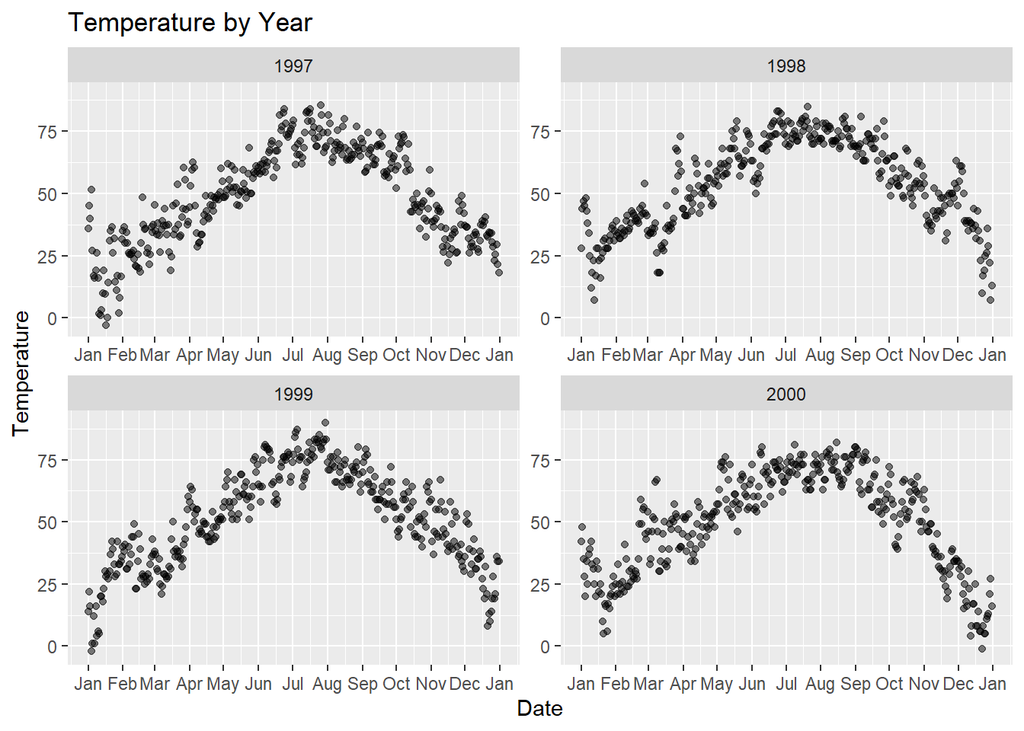

```r
nmmaps <- nmmaps |>
  mutate(date = as.Date(date, format = "%Y-%m-%d"))
ggplot(data=nmmaps,aes(x=date,y=temp)) +
  geom_point(alpha=0.5)+
  facet_wrap(~year,scales="free")+
  labs(x = "Date", y = "Temperature", title = "Temperature by Year")+
  scale_x_date(date_labels = "%b", date_breaks = "1 month")+
  scale_y_continuous(limits = c(min(nmmaps$temp), max(nmmaps$temp)))
```

Interpretation: We see that in 1999, there were hotter days in summer compared to other years; in 2000, the temperature was cooler between November- January. In 1997 and 1999 temperature goes down below 0.

### ii.Examining the relationship using geom_point

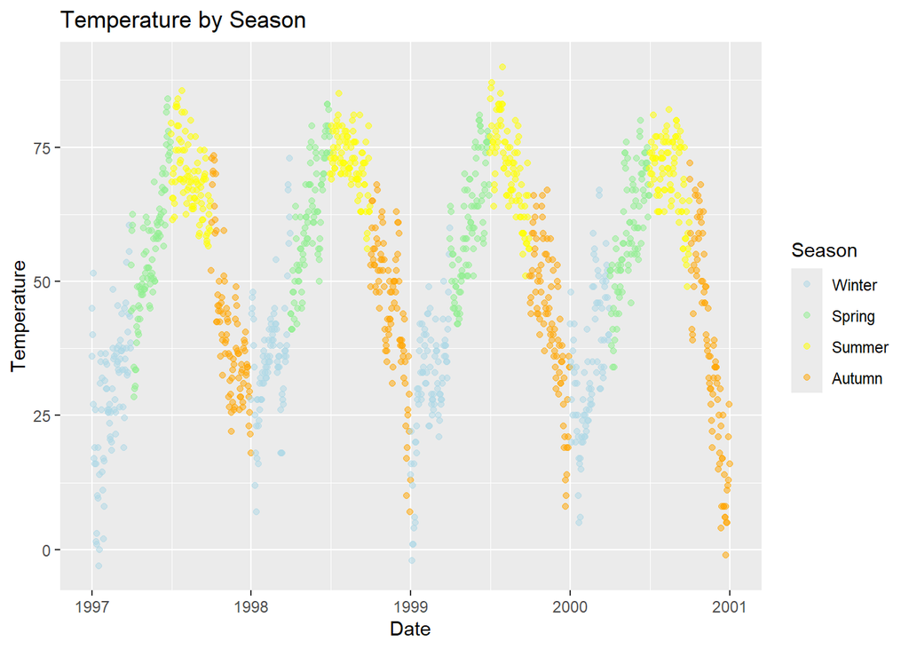

```r
nmmaps$season <- factor(nmmaps$season, levels = c("Winter", "Spring", "Summer", "Autumn"))
season_colors <- c("Winter" = "lightblue",
                   "Spring" = "lightgreen",
                   "Summer" = "yellow",
                   "Autumn" = "orange")
ggplot(nmmaps, aes(x = date, y = temp, color = season)) +
  geom_point(alpha = 0.5) +
  labs(x = "Date", y = "Temperature", color = "Season", title = "Temperature by Season")+
  scale_color_manual(values = season_colors)
```

Interpretation: We see that it gets colder in autumn, and hotter in winter as time passes. We again see that in 1999, there were hotter days in summer compared to other years.

### iii. Relationship between temp and dewpoint

```r
correlation <- cor(nmmaps$temp, nmmaps$dewpoint)
rounded_cor <-round(correlation,3)
print(paste("Correlation coefficient between temperature and dewpoint:", rounded_cor))
```

```
## [1] "Correlation coefficient between temperature and dewpoint: 0.958"
```

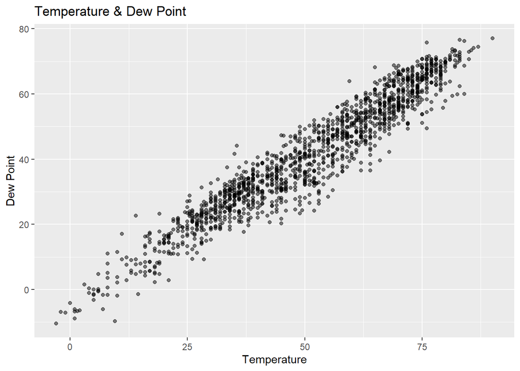

```r
ggplot(nmmaps, aes(x = temp, y = dewpoint)) +
  geom_point(alpha = 0.5) +
  labs(x = "Temperature", y = "Dew Point", title = "Temperature & Dew Point")
```

Interpretation: As we see from the plot and the correlation coefficient we just calculated as 0.958, there is a strong positive correlation between temperature and dew point since 0.958 is close to 1 and the plot is linear.

### Q4

```r
url <- "https://ds.iris.edu/seismon/eventlist/index.phtml"

res <- GET(url)
html_con <- content(res, "text")
html_ulke <- read_html(html_con)

tables <- html_ulke |>
  html_nodes("table") |>
  html_table()
earthquake <- as.data.frame(tables)
str(earthquake)
```

```
## 'data.frame':    943 obs. of  7 variables:
##  $ DATE.and.TIME..UTC.                                           : chr  "19-APR-2024 07:27:34" "19-APR-2024 06:02:04" "19-APR-2024 05:27:56" "19-APR-2024 04:30:28" ...
##  $ LAT                                                           : num  55.26 1.53 41.79 26.61 -58.88 ...
##  $ LON                                                           : num  -157 124.8 81.9 -110.9 -25.2 ...
##  $ MAG                                                           : num  4.8 4.2 4.6 4.2 4.6 5.2 4.5 4.4 4.3 4.5 ...
##  $ DEPTHkm                                                       : int  38 210 10 10 29 10 74 10 10 39 ...
##  $ LOCATION................................Shows.interactive.map.: chr  "SOUTH OF ALASKA" "MINAHASSA PENINSULA, SULAWESI" "SOUTHERN XINJIANG, CHINA" "GULF OF CALIFORNIA" ...
##  $ IRIS.ID...Other.info.                                         : int  11830318 11830337 11830345 11830286 11830289 11830220 11830190 11830152 11830164 11830104 ...
```

```r
earthquake %<>%
  mutate(Class = ifelse(MAG < 4.5, "Minor",
                        ifelse(MAG < 5.5, "Moderate", "Major")))
color_vector <- colorFactor(c("Yellow", "Blue", "Red"),
                            domain = earthquake$Class)
earthquake |>
  leaflet() |>
  addTiles() |>
  addCircles(~LON, ~LAT,
             weight = 10,
             radius = 90,
             popup = paste0(
               "<b>Date: </b>",
               earthquake$DATE.and.TIME..UTC.,
               "<br>",
               "<b>Place: </b>",
               earthquake$ LOCATION................................Shows.interactive.map.,
               "<br>",
               "<b>Depth in km: </b>",
               earthquake$DEPTHkm,
               "<br>",
               "<b>Magnitude: </b>",
               earthquake$MAG),
             label = ~LOCATION................................Shows.interactive.map.,
             color = ~color_vector(Class)) |>
  setView(lng = median(earthquake$LON),
          lat = median(earthquake$LAT),
          zoom = 2)
```

[interactive chart not shown]